# Assignment03

Amita

September 16, 2018

# Q1 - GitHub Cloning

Create a new directory

Navigate to the appropriate directory

Clone the repository

# Q2 - Data Summary

```
##  [1] "PassengerId" "Survived"    "Pclass"      "Name"        "Sex"
##  [6] "Age"         "SibSp"       "Parch"       "Ticket"      "Fare"
## [11] "Cabin"       "Embarked"
```

## 2b

Output the respective count of females and males aboard the Titanic. Plot the frequency of females and males. Be sure to give an accurate title and label the axes.

**Count of females and males:**

`r summary(TitanicData$Sex)`

`## female male ## 314 577`

`r plot(x=TitanicData$Sex, xlab="Gender", ylab="Passengers", main="Frequency of females and males")`

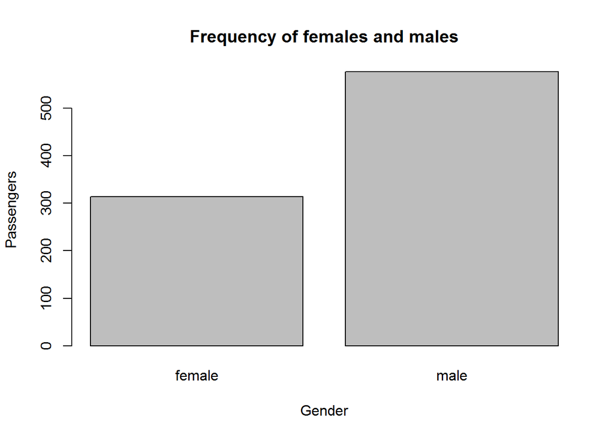

## 2c

`r sapply(TitanicData[,c('Age','Fare','Survived')],mean,na.rm=T)`

`## Age Fare Survived ## 29.6991176 32.2042080 0.3838384`

# Q3 - Function Building

```r
#loading the sleep dataset from the Web
sleep=read.table('http://talklab.psy.gla.ac.uk/L1_labs/lab_1/homework/sleep_data_01.csv',header=T,sep=',')
```

## 3a,b,c,d

```r
getReport<-function(sleep){

  #3a: Create objects for the median Age, the minimum and maximum Duration of sleep, and the mean and standard deviation of the Rosenberg Self Esteem scale (RSES). You may need to specify a few options like in Problem 2 and live session.
  ageMedian = median(sleep$Age,na.rm=T)
  durationMin = min(sleep$Duration,na.rm=T)
  durationMax = max(sleep$Duration,na.rm=T)
  RSESMean = mean(sleep$RSES,na.rm=T)
  RSESSD = sd(sleep$RSES,na.rm = T)

  #3b: Create a data.frame object called report: it should consist of the median age, the RSES mean and standard deviation respectively divided by five (since there are five questions and these scores are summed), and the range of Duration (the statistical definition of range; it should be a single number.)
  report=data.frame(ageMedian,RSESMean = RSESMean/5,RSESSD = RSESSD/5, range = durationMax - durationMin)

  #3c: Change the column names of this data.frame to MedianAge, SelfEsteem, SE_SD, and DurationRange.
  names(report) = c('MedianAge','SelfEsteem','SE_SD','DurationRange')

  #3d Round the report to at most 2 digits: leave this as the closing line to the function.
  sapply(report,round,2)
}
```

## 3e

Finally, run the function on your sleep data to show the output.

```r
getReport(sleep)
```

```
##     MedianAge    SelfEsteem         SE_SD DurationRange
##         14.00          3.62          1.24          7.00
```

# Q4

FiveThirtyEight Data (30 points): Navigate on GitHub to https://github.com/rudeboybert/fivethirtyeight and read README.md. It will include everything you need

## 4a.

Install the fivethirtyeight package.

```r
#install.packages("fivethirtyeight", build_vignettes = TRUE)
library(fivethirtyeight)
```

## 4b

In the listing of Data sets in package ‘fivethirtyeight,’ assign the 22nd data set to an object ‘df.’

```r
datasets = data(package = "fivethirtyeight")
item = as.character(datasets$results[22,'Item'])
message('the 22nd data set is ',item)
```

```
## the 22nd data set is college_recent_grads
```

```r
df=eval(parse(text=paste0('fivethirtyeight::' , item )))

# I could have done  df=fivethirtyeight::college_recent_grads, but this is more fun....
```

## 4c

Use a more detailed list of the data sets to write out the URL in a comment to the related news story

```r
#vignette("fivethirtyeight", package = "fivethirtyeight")
#df$comment = 'http://fivethirtyeight.com/features/the-economic-guide-to-picking-a-college-major/' ?
#should I add to the data frame?
```

**Related news Story is here:** http://fivethirtyeight.com/features/the-economic-guide-to-picking-a-college-major/

## 4d

Using R command(s), give the dimensions and column names of this data frame.

Dimension of the data frame:

```r
message(dim(df)[1], ' Rows, ', dim(df)[2],' Columns')
```

```
## 173 Rows, 21 Columns
```

Column Names of the data frame:

```r
message(paste0(names(df),collapse=', '))
```

```
## rank, major_code, major, major_category, total, sample_size, men, women, sharewomen, employed, employed_fulltime, employed_parttime, employed_fulltime_yearround, unemployed, unemployment_rate, p25th, median, p75th, college_jobs, non_college_jobs, low_wage_jobs
```

# Q5 Data Summary

## 5a

Write an R command that gives you the column names of the data frame. Right after that, write one that counts the number of columns but not rows. Hint: The number should match one of your numbers in Question 1d for dimensions.

```r
names(df)
```

```
##  [1] "rank"                        "major_code"
##  [3] "major"                       "major_category"
##  [5] "total"                       "sample_size"
##  [7] "men"                         "women"
##  [9] "sharewomen"                  "employed"
## [11] "employed_fulltime"           "employed_parttime"
## [13] "employed_fulltime_yearround" "unemployed"
## [15] "unemployment_rate"           "p25th"
## [17] "median"                      "p75th"
## [19] "college_jobs"                "non_college_jobs"
## [21] "low_wage_jobs"
```

```r
length(names(df))
```

```
## [1] 21
```

```r
ncol(df)
```

```
## [1] 21
```

## 5b

Generate a count of each unique major_category in the data frame. I recommend using libraries to help. To be clear, this should look like a matrix or data frame containing the major_category and the frequency it occurs in the dataset. Assign it to major_count.

```r
major_count = df %>%
  group_by(major_category) %>%
  summarize(count=n())
 DT::datatable(major_count)
```

|  | major_category | count |
| --- | --- | --- |
| 1 | Agriculture &amp; Natural Resources | 10 |
| 2 | Arts | 8 |
| 3 | Biology &amp; Life Science | 14 |
| 4 | Business | 13 |
| 5 | Communications &amp; Journalism | 4 |
| 6 | Computers &amp; Mathematics | 11 |
| 7 | Education | 16 |
| 8 | Engineering | 29 |
| 9 | Health | 12 |
| 10 | Humanities &amp; Liberal Arts | 15 |

[output cut: 6 more lines]

## 5c

To make things easier to read, put par(las=2) before your plot to make the text perpendicular to the axis. Make a barplot of major_count. Make sure to label the title with something informative (check the vignette if you need), label the x and y axis, and make it any color other than grey. Assign the major_category labels to their respective bar. Flip the barplot horizontally so that bars extend to the right, not upward. All of these options can be done in a single pass of barplot(). Note: It’s okay if it’s wider than the preview pane

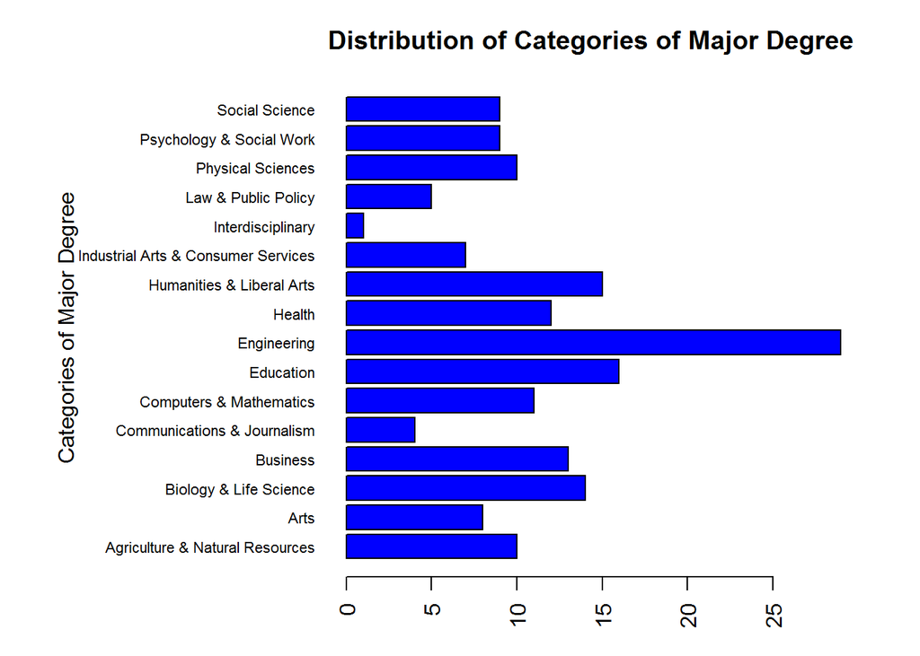

```r
par(mar=c(3,13,3,3))
par(mgp=c(10,1,0))
barplot(major_count$count,names.arg=major_count$major_category
        ,main='Distribution of Categories of Major Degree'
        ,horiz=T,las=2,cex.names = .7
        ,xlab = 'Count of Categories', ylab='Categories of Major Degree'
        ,col='blue'
        )
```

## 5d

Write the fivethirtyeight data to a csv file. Make sure that it does not have row labels.

```r
file=paste0(item,'.csv')
write.csv(df,row.names = F,file=file)
message('saved as: ',file)
```

```
## saved as: college_recent_grads.csv
```

# Q6 Codebook

## 6a

Start a new repository on GitHub for your SMU MSDS homework. On your local device, make sure there is a directory for Homework at the minimum; you are welcome to add whatever you would like to this repo in addition to your requirements here.

**The repo is here:** https://github.com/ABehuria/Fall_SMU_MSDS

## 6b

Create a README.md file which explains the purpose of the repository, the topics included, the sources for the material you post, and contact information in case of questions. Remember, the one in the root directory should be general. You are welcome to make short READMEs for each assignment individually in other folders.

**the READMe.md is saved in the main folder:**https://github.com/ABehuria/Fall_SMU_MSDS/blob/master/README.md

## 6c

In one (or more) of the nested directories, post your RMarkdown script, HTML file, and data from ‘fivethirtyeight.’ Make sure that in your README or elsewhere that you credit fivethirtyeight in some way.

## 6d

In your RMarkdown script, please provide the link to this GitHub so the grader can see it.

**Link to the GitHub:** https://github.com/ABehuria/Fall_SMU_MSDS